# Detection of Knee Pathologies from MRI

Using Deep Learning Models (CNNs)

Bala Raju Pidatala & Sabna Balasubramoniapillai

Advisor: Dr. Achraf Cohen

2026-04-28

## Introduction

### The Clinical Problem

- Knee disorders including osteoarthritis and ACL and meniscal tears are some of the most common musculoskeletal disorders worldwide.
- X-ray does not show soft tissue very well. Early changes are easily overlooked.
- MRI is considered the “gold standard” due to high contrast, multiplanar imaging and excellent soft-tissue detail.

### Why MRI Needs AI?

- Machine assisted MRI reading is fast, reliable and removes variability between readers.
- Analysis of medical images and clinical documents can aid diagnosis, but requires automation to increase effectiveness.

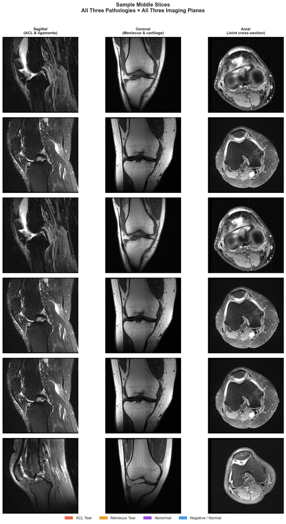

Sample knee MRI slices

## Research Objective

**Core Research Question**

> Can a 3D CNN learn spatial and anatomical information from multi-plane knee MRI volumes to accurately detect multiple knee pathologies simultaneously?
- Develop and train a 3D Convolutional Neural Network that can simultaneously detect ACL, Meniscus, and general knee abnormalities.
- Use the Stanford MRNet dataset which is a publicly available collection of clinical knee MRI scans from multiple centers collected between 2001 and 2012.
- This task requires developing three separate dual-classification problems and assessing them individually as well as jointly. Deep Fusion (multi-plane fusion: sagittal + coronal + axial) with learnable plane-attention weights.
- Evaluate AUC-ROC, accuracy, sensitivity, specificity, F1-score - for all three classification tasks.

**Three Binary Classification Tasks**

| Task | What is Detected | Clinical Use |
| --- | --- | --- |
| ACL Tear | Ligament rupture present (1) vs. absent (0) | Surgical planning |
| Meniscus Tear | Meniscal damage present (1) vs. absent (0) | Surgical vs. conservative care |
| Abnormality | Any knee pathology present (1) vs. absent (0) | Screening and triage |

## Dataset: Stanford MRNet

- Open knee MRI data set - Stanford University School of Medicine
- Clinical scans collected from 2001–2012 (11-year period)
- Each study is provided in 3 imaging planes, (Sagittal, Coronal, Axial)
- Capable of being used for 3 binary diagnostic projects: ACL tear, Meniscus tear, Any Abnormality.
- Binary classification label format: binary CSV (0s and 1s where 1s indicate presence).

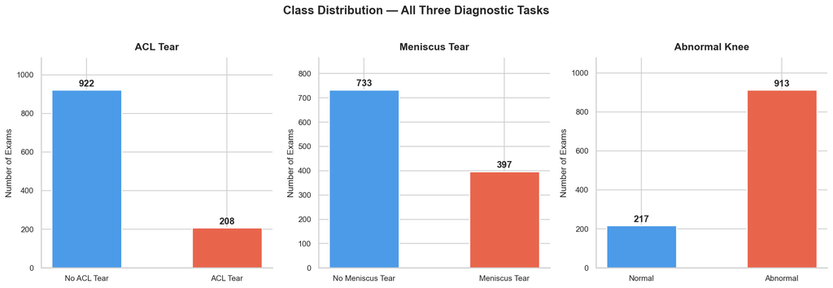

Class distribution across all three diagnostic tasks

⚠ ACL imbalance: 4.4:1 | Abnormal imbalance: 4.2:1 (reversed)  
Mitigated by Focal Loss + data augmentation + Youden’s Index thresholding

**1,130**Total MRI Studies

**3**Imaging Planes

**3**Diagnostic Tasks

**11 yrs**Data Collection

## Exploratory Data Analysis

Sagittal

μ = 30.4 slices

Range: 17–51

Coronal

μ = 29.8 slices

Range: 17–58

Axial

μ = 34.3 slices

Range: 19–61

- **Preprocessing Decision**
- Variable slice depth normalised to standardise all to 32 slices (cropped or zero-padded)
- Pixel intensity: right-skewed with major contributions from the 0–80 intensity range consistent with expected T2-weighted knee MRI signal.
- Per-channel zero-mean unit variance normalization (standardization) improves training stability for 3D CNN.
- Visual examination revealed widespread disease throughout the specimen, affecting multiple 10 mm sections, therefore a three-dimensional analysis was warranted.

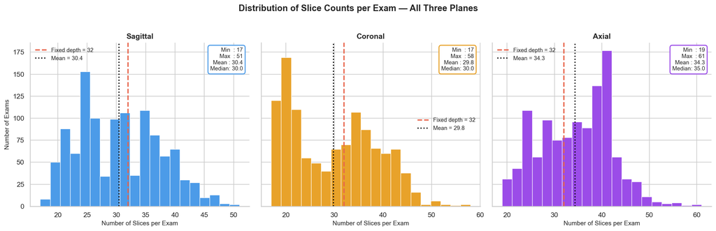

Slice count distribution per exam across all planes

## Methodology: 3D CNN Architecture

**Key Observations** Why 3D CNN Instead of 2D CNN? - 2D CNNs process each slice independently — no spatial context across depth  
- 3D CNNs apply kernels across height, width, and depth simultaneously  
- This preserves inter-slice relationships essential for volumetric knee anatomy

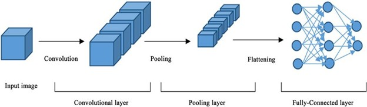

CNN Architecture

## Training Setup

### Hyperparameters

| Parameter | Value |
| --- | --- |
| Optimizer | Adam with weight decay |
| Learning rate scheduler | ReduceLROnPlateau |
| Epochs | 15 |
| Loss function | Focal Loss |
| Batch | 2 (due to 3D CNN memory cost) |
| Decision threshold | Youden’s Index (per task) |

### Addressing Class Imbalance

Class Weights: [4.43, 1.85, 0.24]

It indicates strong imbalance (ACL is rare, Abnormal is mostly positive)

- **Focal Loss** — Focuses on hard, misclassified examples
  - Focal Loss helps the model learn better from minority classes
- **Data Augmentation** — Random flips, rotations, intensity scaling
- **Youden’s Index** — Maximizes (Sensitivity + Specificity − 1)
  - Best threshold for ACL: 0.356
  - Best threshold for Meniscus: 0.400
  - Best threshold for Abnormal: 0.497

## Training Loss Curve

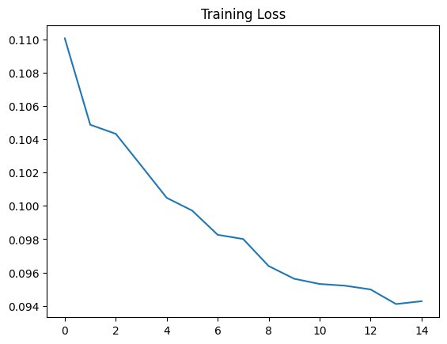

Training Loss Curve

**Key Observations:**

- Training loss decreases steadily over epochs, indicating effective learning.
- The curve shows smooth convergence without major oscillations.
- No clear over-fitting trend observed (no divergence between training stability and expected validation behavior).

## Results: ACL Tear Detection

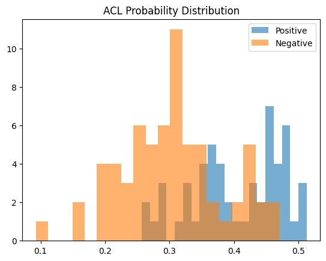

Probability Distribution - ACL

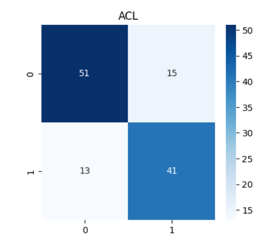

Confusion Matrix - ACL

**Key Observations**

- The model shows reasonable separation between ACL and non-ACL cases, with some overlap in the mid-probability range indicating uncertain predictions.
- The confusion matrix shows a balanced trade-off between sensitivity and specificity.
- Moderate false positives and false negatives are present, indicating room for improvement.

## Results: Meniscus Tear Detection

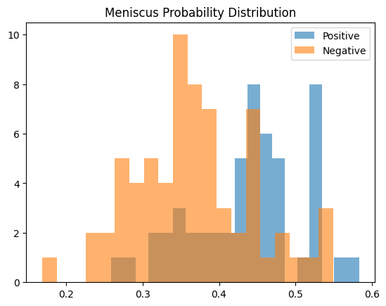

Probability Distribution -Meniscus

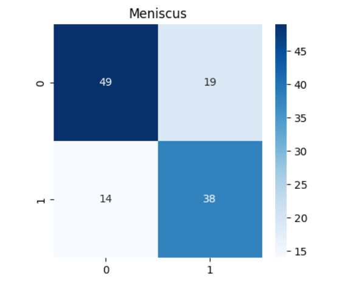

Confusion Matrix-Meniscus

**Key Observations**

- The probability density function shows that the Model exhibits weaker class separation compared to ACL. Overlap region leads to higher false positives.
- The confusion matrix shows higher false positives indicate over-prediction of tears. More challenging classification compared to ACL

## Results: Abnormality Detection

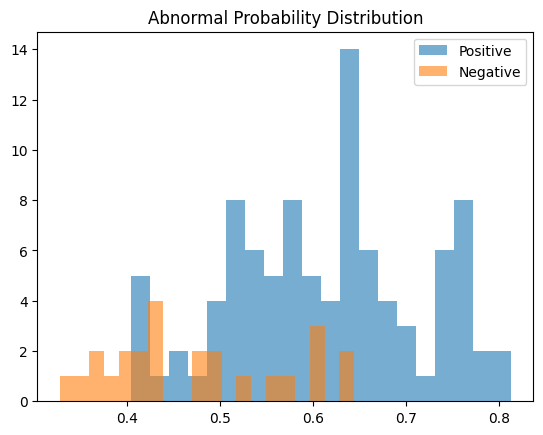

Probability Distribution -Abnormal

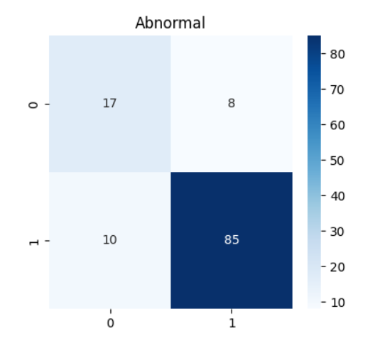

Confusion Matrix-Abnormal

## ROC Curves and AUC Scores

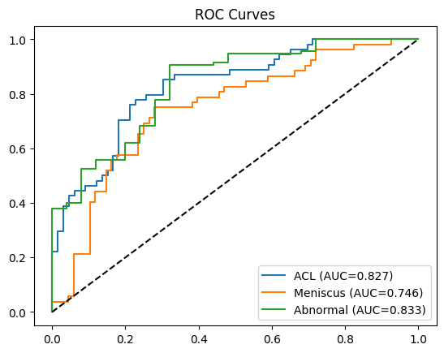

ROC_Curve

**Key Observations:**

## Learned Plane Attention Weights

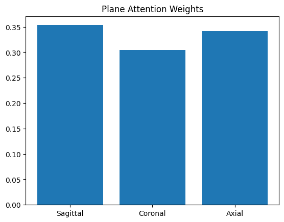

Plane Attention Weights

**Key Observations:**

- Model assigns different importance to each MRI plane
- Higher weight = more influence on final prediction
- Shows model is learning **which view is more informative**
- Not treating sagittal, coronal, and axial equally
- Provides interpretability into model decision-making

## Summary of Results

**Validation Metrics — All Three Tasks**

| Pathology | AUC-ROC | Accuracy | Sensitivity | Specificity | F1-Score |
| --- | --- | --- | --- | --- | --- |
| ACL Tear | 0.827 | 0.767 | 0.759 | 0.773 | 0.745 |
| Meniscus Tear | 0.746 | 0.725 | 0.731 | 0.721 | 0.697 |
| **Abnormality** | **0.833** | **0.850** | **0.895** | 0.680 | **0.904** |

## Future Work

01

Larger & Multi-Centre Datasets

Access diverse, multi-institution datasets to improve model generalization across MRI platforms and patient populations

03

Federated Learning

Train across institutions without sharing patient data - preserving privacy while benefiting from larger effective datasets

04

Vision Transformer Architectures

Explore transformer-based volumetric models that capture long-range spatial relationships beyond the local scope of convolutional kernels

06

Multimodal Integration

Combine MRI data with clinical metadata (age, BMI, patient history) for richer diagnostic predictions

## References

- Avesta, Arman, Sajid Hossain, MingDe Lin, Mariam Aboian, Harlan M Krumholz, and Sanjay Aneja. 2023. “Comparing 3D, 2.5 d, and 2D Approaches to Brain Image Auto-Segmentation.” Bioengineering 10 (2): 181.
- Awan, Mazhar Javed, Mohd Shafry Mohd Rahim, Naomie Salim, Amjad Rehman, Haitham Nobanee, and Hassan Shabir. 2021. “Improved Deep Convolutional Neural Network to Classify Osteoarthritis from Anterior Cruciate Ligament Tear Using Magnetic Resonance Imaging.” Journal of Personalized Medicine 11 (11): 1163. https://doi.org/10.3390/jpm11111163.
- Bien, Nicholas, Pranav Rajpurkar, Robyn L Ball, Jeremy Irvin, Allison Park, Erik Jones, Michael Bereket, et al. 2018. “Deep-Learning-Assisted Diagnosis for Knee Magnetic Resonance Imaging: Development and Retrospective Validation of MRNet.” PLoS Medicine 15 (11): e1002699. https://doi.org/10.1371/journal.pmed.1002699.

Thank You

Bala Raju Pidatala | Sabna Balasubramoniapillai

Advisor: Dr. Archaf Cohen

IDC 6940 — Capstone Projects in Data Science | Spring 2026

Detection of Knee Pathologies from MRI Using Deep Learning Models (CNNs)

IDC 6940 | Spring 2026 | Knee MRI Pathology Detection